# Chapter 2 - The Causes and Quantification of Population Vulnerability

## Chapter 2 summary

Chapter 2 of Morris and Doak’s *Quantitative Conservation Biology: Theory and Practice of Population Vulnerability Analysis* discusses how a population’s vulnerability is influenced by factors like temporal variability (e.g. environmental stochasticity, demographic stochasticity, and catastrophic/bonanza events). All of these factors can negatively impact overall population growth by introducing variability in the population’s vital rates. As a result of variability, populations can decrease in size even if the arithmetic mean of population growth indicates positive growth (i.e. $\lambda_A > 1$).

The effects of temporal variability are magnified as we project further forward in time.

## Box 2.1 - Simulating population trajectories under temporal variability

This example model uses the basic equation of population growth, $N_{t+1} = \lambda_t N_t$ (Eq’n 2.1), but randomly draws the value of $\lambda_t$ from a set of observed values of $\lambda$. While Morris and Doak provide their code in MATLAB, I have translated it to a free and open-source statistical language, R, below - there are also comments to indicate which parts of the MATLAB code correspond to R commands. All variable names are kept the same from the original MATLAB code, only the functions and code structure have been modified.

`r`r ### PROGRAM RandDraw.m, translated to RandDraw.R ### Performs multiple simulations of discrete exponential growth trajectores using a set of observed lambda values

# This code only uses three optional libraries, ggplot2 and the tidyverse packages tidyr and dplyr

# These packages are only used to make the plots produced by population simulations, but are not necessary for the actual simulations.

# If you’d rather not install and load these libraries, it won’t affect the population simulation steps

library(ggplot2) library(tidyr) library(dplyr)

# The observed lambda values to sample from. Each has equal draw probability.

lams <- c(1.00, 1.98, 1.02, 0.92, 0.53) # Original population size at t=0 numzero <- 29 # Number of years to simulate tmax <- 100 # How many replicates of the time series should be created numreps <- 100 # We ignore ‘outname’ in R because our results will exist in our R session

# This replaces the rand(…) MATLAB command, sets the seed for the random number generator

# SN: Unlike MATLAB, R does not require setting the seed for randomization, but setting it to 123 will ensure that your results match the ones I generated here

set.seed(seed=123) numlambs <- length(lams) # How many lambda values are there?

# To generate a matrix of lambdas to use for each year/simulation:

# a. Create a 100x100 matrix (one index for each value of 1:tmax and 1:numreps

# b. For each value in the matrix, randomly sample a value of lambda (with replacement) from the lams list

# This combines the commands that create intvalues and lambdas in the original M+D MATLAB code

lambdas <- matrix(nrow=tmax, ncol=numreps, data=sample(lams, tmax*numreps, replace=T)) dim(lambdas) # Just to check if it matches our expectations of size and values

```
[1] 100 100
```

`r`r unique(as.numeric(lambdas))

```
[1] 1.98 0.92 1.02 0.53 1.00
```

`r`r # Now we need to initialize population size initpopsize <- rep(numzero, numreps) # initpopsize is a length-100 vector filled with 29, our starting population size

# For each year of the simulation, multiply the current population size by the lambdas*last year’s population size # a) Initialize the popsizes matrix with NaN values - this will be populated later # b) For each year, calculate the new population size following deterministic growth with that year’s lambda_t # SN: There is likely a faster/more code-efficient way to do this; please raise an Issue on GitHub if you know a better solution popsizes <- matrix(nrow=tmax, ncol=numreps, data=NaN) popsizes[1,] <- initpopsize # The first row of our simulation (i.e. our first year) is 29 for all replications # Now iterate over years to calculate the new population size # If the previous year’s population is less than one, enforce a new population size of 0 # This ensures that we don’t see populations with less than 1 individual (e.g. 0.5) rebuilding the population for(y in 2:tmax){ lambdas.year <- lambdas[y-1,] # Temporary vector indicating whether the population is extinct in the past year or not notextinct.tmp <- (popsizes[y-1,]>=1)*1

popsizes[y,] <- popsizes[y-1,]*lambdas.year*notextinct.tmp }

# Let’s check on how the first few years of simulation look in the first 10 replications

# after giving the matrix some better column and row names

colnames(popsizes) <- paste0(‘rep’,1:numreps) # rownames(popsizes) <- paste0(‘y’,1:tmax)

head(popsizes[,1:10])

```
         rep1     rep2     rep3     rep4      rep5     rep6     rep7     rep8     rep9     rep10
[1,] 29.00000 29.00000 29.00000 29.00000 29.000000  29.0000  29.0000 29.00000  29.0000 29.000000
[2,] 57.42000 29.58000 57.42000 26.68000 15.370000  57.4200  57.4200 15.37000  29.5800 15.370000
[3,] 52.82640 58.56840 30.43260 26.68000 15.370000 113.6916  52.8264 30.43260  58.5684 15.677400
[4,] 53.88293 59.73977 27.99799 24.54560  8.146100 225.1094 104.5963 30.43260  58.5684  8.309022
[5,] 28.55795 31.66208 28.55795 22.58195  8.309022 225.1094 207.1006 16.12928  58.5684  8.475202
[6,] 15.13571 32.29532 29.12911 20.77540 16.451864 445.7165 207.1006 31.93597 115.9654  7.797186
```

We can already see the impact that a variable $\lambda_t$ can have on population growth dynamics.

`r`r # Now identify situations in which the population went extinct notextinct <- (popsizes>=1)*1 table(notextinct)

```
notextinct
   0    1
1957 8043
```

In 1957 instances, we saw extinction.

`r`r # Find the biggest population size maxN <- 0.5*max(popsizes) maxN

```
[1] 24916.48
```

`r`r # Calculate the geometric mean for lambda stochL <- prod(lams)^(1/numlambs) # Calculate the expected population at tmax expectedNt <- numzero*(stochL^tmax)

cat(‘Stochastic lambda:’, stochL); cat(‘N at t=tmax:’, expectedNt)

[output not shown]

Overall, we should expect the population to decrease over time (compared to the arithmetic mean, 1.09)

`r`r # We’re going to skip writing to the worksheet and plot the population sizes using ggplot # Find the average population size for each year, averaging across replications averageN <- data.frame(averagePop=rowMeans(popsizes[,1:100]), year=1:tmax)

# Let’s get to the histogram in a moment, first let’s see a time series

# To do this, I’m going to first rearrange the dataframe using tidyr

popsizes.mod <- as.data.frame(popsizes) %>% gather(key = rep, value = populationSize) %>% mutate(year = rep(1:tmax,numreps)) # I need to add the +1 here to account for the annual mean values

ggplot(data=as.data.frame(popsizes.mod), aes(x=year, y=populationSize, color=rep)) + geom_line(alpha=0.7) + # plot out our replicated series geom_line(data=averageN, aes(y=averagePop, x=year), color=‘black’, size=1.2) + # Plot the average size overtop ylim(0,2000) + # limit our y axis from 0 to 2000 theme(legend.position = ‘none’) # get rid of the legend

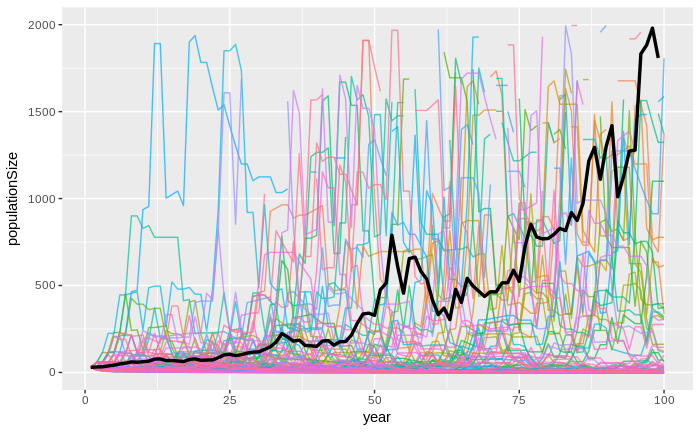

Now let’s make those histograms after bounding our data to be below 2000 individuals (like the y-axis above).

`r`r bounded.popsizes <- popsizes.mod bounded.popsizes$populationSize[which(bounded.popsizes$populationSize>2000)] <- 2000

# Let’s check that worked:

summary(bounded.popsizes)

```
     rep            populationSize          year
 Length:10000       Min.   :   0.000   Min.   :  1.00
 Class :character   1st Qu.:   3.346   1st Qu.: 25.75
 Mode  :character   Median :  23.334   Median : 50.50
                    Mean   : 209.800   Mean   : 50.50
                    3rd Qu.: 102.611   3rd Qu.: 75.25
                    Max.   :2000.000   Max.   :100.00
```

`r`r # Good, the max value is 2000.

`r`r # Histogram for the first 5 years ggplot(data=bounded.popsizes[which(bounded.popsizes$year %in% c(1:5)),], aes(x=populationSize)) + geom_histogram()

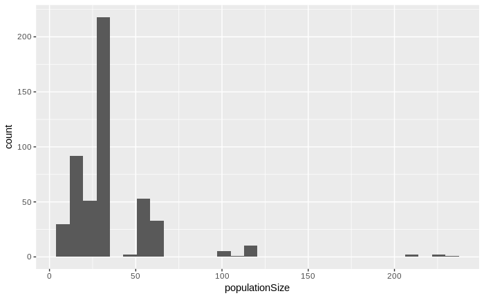

`r`r # For the first 20 years ggplot(data=bounded.popsizes[which(bounded.popsizes$year %in% c(1:20)),], aes(x=populationSize)) + geom_histogram()

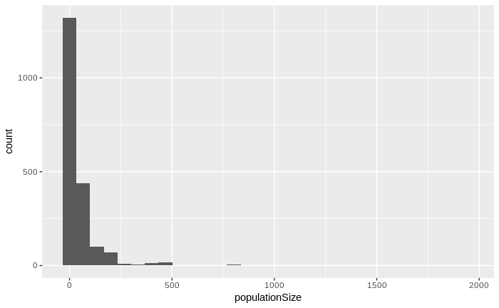

`r`r # For the full 100 years ggplot(data=bounded.popsizes, aes(x=populationSize)) + geom_histogram()

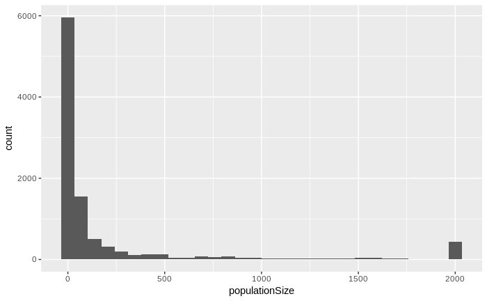

That’s the end of the practical example in M+D’s PVA textbook. The remainder of the chapter discusses the influence of negative density dependence, positive density dependence (i.e. Allee effects), and genetic factors on population growth and viability.

## Density dependence

### Negative density dependence

- **Density dependence** = a change in individual performance as the size or density of the population changes; embodied by the logistic growth equation $N_{t+1} = N_t + rN_t(1-\frac{N_t}{K})$ # CHECK THE ABOVE EQUATION
- can cause PVA to over or underestimate the true viability of a population depending on how growth rates respond to density
- relationship is typically nonlinear - effects may not manifest until high population densities
- if we assume linear negative density dependence - greater probability of species extinction; this is because **negative density dependence maintains the population at a low level** because higher densities = lower fecundity
  - at the same time, because fecundity is higher at low densitites, the risk of extinction **can also decrease the face of negative density dependence** as a result of reproductive compensation

In contrast, if density dependence is introduced only at a high densities, there will be **no added protection of density dependence as fecundity is not increased at low densities**. If PVA assumed perfect density dependence, this would artificially increase our confidence that the population will persist.

As a result, many PVAs ignore density dependence although many methods exist to estimate and include negative density dependence in PVA (or use a simple population ceiling). It is usually best to include no density dependent effects if careful testing of population data indicate no density dependence *or* create a range of models with different strengths/forms of density dependence.

### Positive density effects/Allee effects

- **increase in population growth rate as size increases** - arise from improved mating success, group defense*, or group foraging* as density increases (majority of evidence from sessile plants)

* - only important for some species, while all affected by mate success

- **+ DD only rarely detected with census data** - e.g. using quadratic regression between per-capita population growth rate and N in birds/mammals with census data @ low sizes - expected to see a hump-shaped curve
- neither analysis found any evidence for + DD
- Myers et al. looked for + DD in fish - fit BH models with and without allee effects - in only 3/128 stocks did allee effects fit the recruitment data better than BH without
- logistic regression of butterflies showed proportion of small populations that grew or remained constant from *t* to *t+1* was positively related to population size at *t* - looked at replication of multiple populations in space rather than a single population over time
- **thus we do not have a good idea of how Allee effects operate or how strong they are, even though they are almost certainly operating**
  - we can incorporate these into PVas, but the limits of our data can thwart inclusion of positive density effects; best solution often to set a quasi-extinction threshold high enough to avoid Allee effects
  - But what this level is can be confusing (e.g. passenger pigeons may have been 10,000; but for some plants it is more like 20) - again, best to run a set of PVA models and compare their outcomes